# Final Project - NFTs

Matthew Greene & Yohari Hernandez

# Are NFTs a Good Investment?

The data https://www.kaggle.com/mathurinache/nft-history-sales I sourced this data from the kaggle public datasets. The purpose of this dataset was to help on how to make money using NFT and AI. We are going to manipulate this data to look for trends and speculate about the future of the NFT market.

```
##          Date Sales_USD_cumsum Number_of_Sales_cumsum
## 1  2017-06-22             0.00                      0
## 2  2017-06-23          1020.30                     19
## 3  2017-06-24          2261.14                     40
## 4  2017-06-25          2778.69                     53
## 5  2017-06-26          3203.32                     67
## 6  2017-06-27          5296.23                    100
## 7  2017-06-28          6543.49                    115
## 8  2017-06-29          8729.21                    153
## 9  2017-06-30         10437.36                    174
## 10 2017-07-01         13578.16                    184
##    Active_Market_Wallets_cumsum Primary_Sales_cumsum Secondary_Sales_cumsum
## 1                             0                    0                     NA
## 2                             8                    0                     19
## 3                            21                    0                     21
```

[output cut: 18 more lines]

### Active Wallets

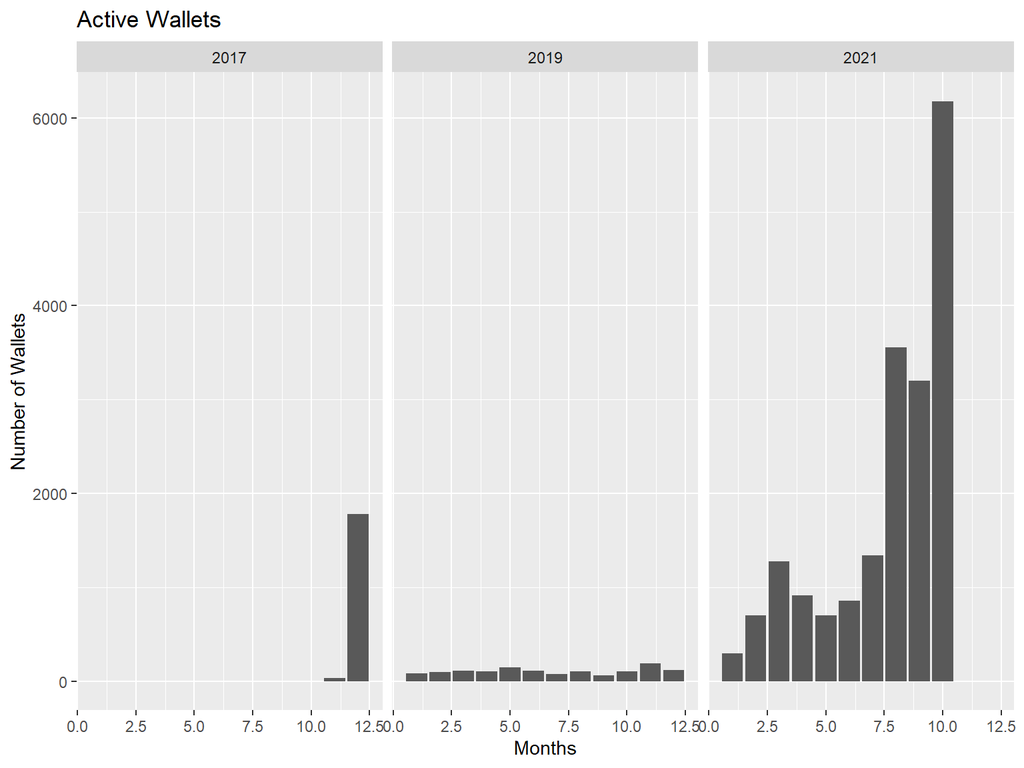

The number of active wallets reflects the size of the population potentially trading in NFTs. Our plot with the number of active wallets shows rapid growth, especially during 2021. Our takeaway is that people are becoming more comfortable with the idea of NFTs having real value. (Notice there is a random peak in December of 2017, we will speculate why later.)

### Peak Sales 2021

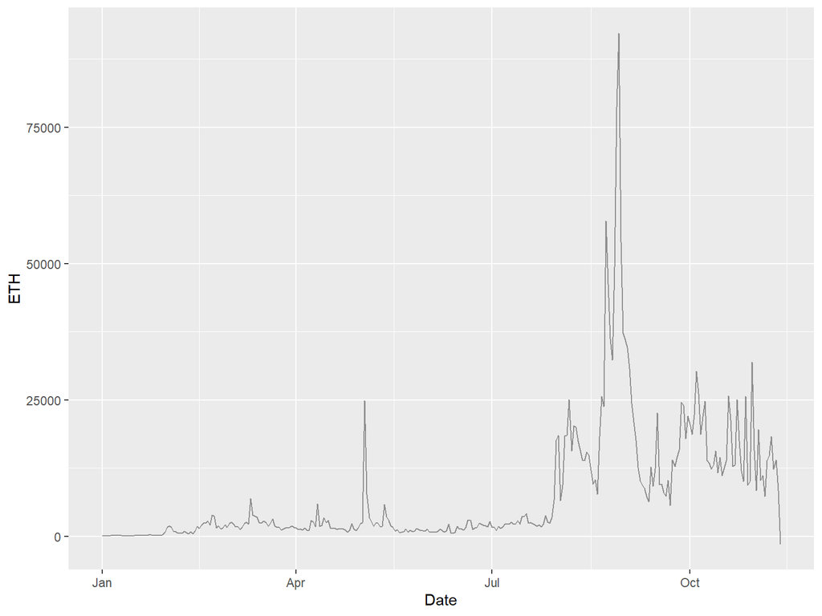

```
##          Date Sales_USD_cumsum Number_of_Sales_cumsum
## 1  2021-08-29       4978931765                7897699
## 2  2021-08-28       4590295407                7839873
## 3  2021-08-23       3566930620                7601607
## 4  2021-08-30       5206486952                7947449
## 5  2021-08-27       4258766144                7791478
## 6  2021-08-24       3761880404                7643809
## 7  2021-08-31       5363242859                8006710
## 8  2021-08-25       3914466731                7690685
## 9  2021-09-01       5514959670                8053004
## 10 2021-09-02       5660670177                8072745
##    Active_Market_Wallets_cumsum Primary_Sales_cumsum Secondary_Sales_cumsum
## 1                        494706              4857493                  31354
## 2                        489991              4831021                  28474
## 3                        471816              4724813                  22451
```

[output cut: 29 more lines]

### Daily Sales Average

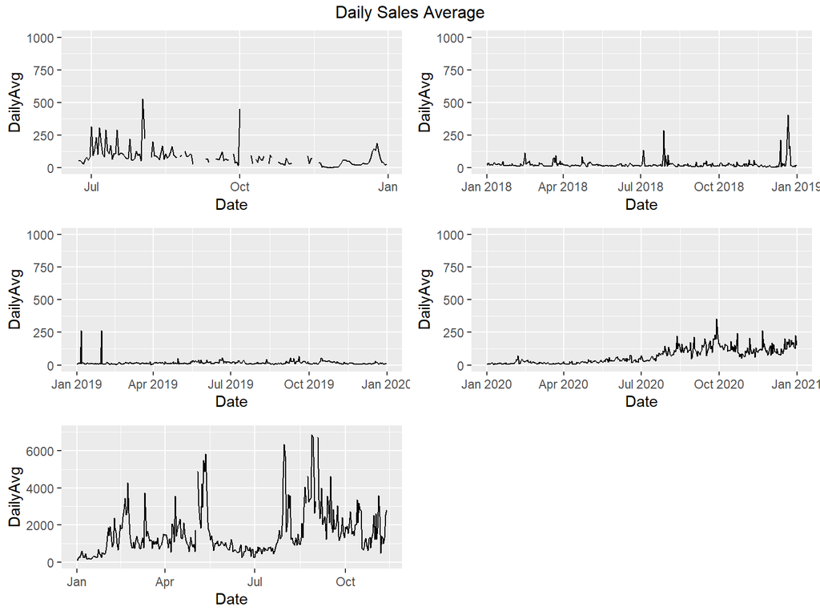

The plots with the daily average sale price per NFT shows that despite sporadic spikes the average sales price is still trending upwards. We take that as an indicator that NFTs are holding their value right now, even with the surge in the number of NFTs on the market.

### Primary vs Secondary Sales

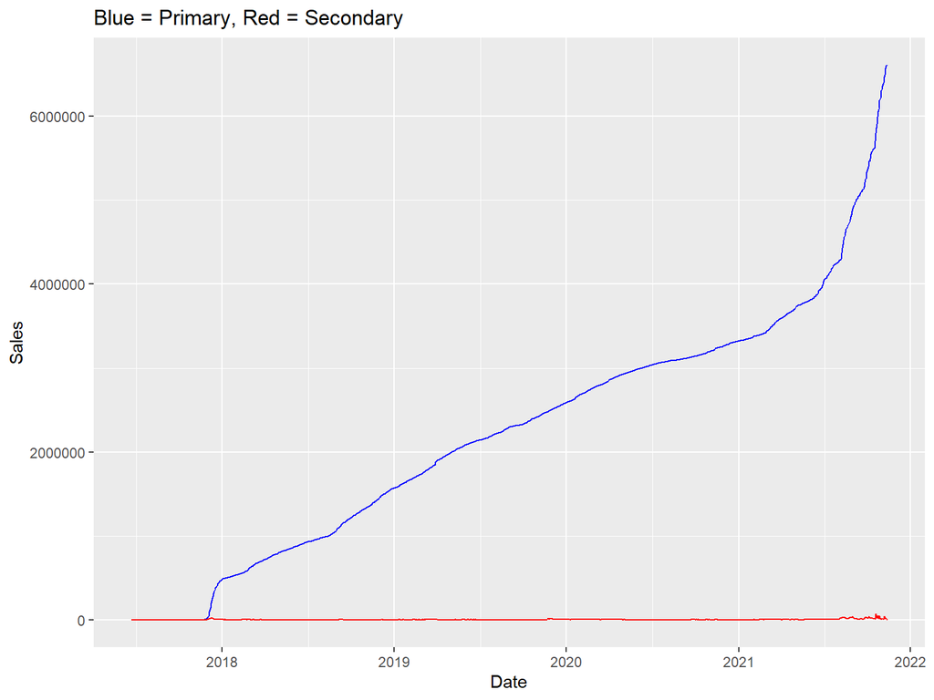

The vast difference in the primary vs secondary sales indicates that the majority consumers aren’t selling their NFTs, rather treating the NFTs like an investment. It also tells us that creators are getting the majority of the profits. Some artists even get a royalty on the resale of their NFTs. The advantage of easy authentication and fair artist compensation could be a driving force behind maintaining NFT relevance.

### Why was there a spike in December 2017?

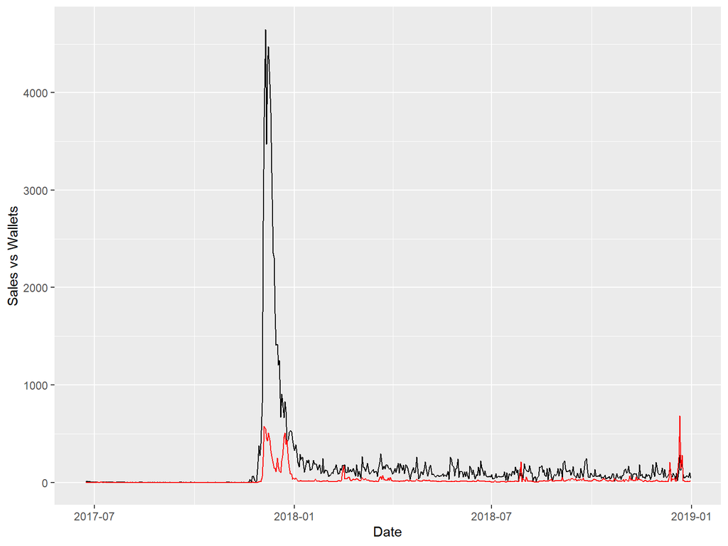

We noticed a spike in December 2017 in both the number of active wallets and number of sales that did not follow the typical trend in the data. After doing some research we found a BBC article from the same month and year reporting on a surge in sales of “Crypto Kitties” (one of the earliest examples of NFTs). Etherium reported a “sixfold increase in pending transactions”[@BBC] that would account for the spike.

### Google Trends

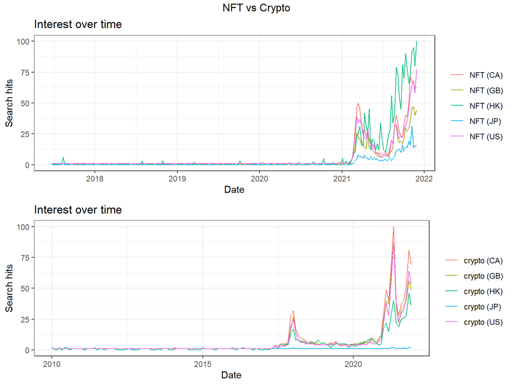

We used google trends to try and quantify interest in NFTs and Cryptocurrency. The similarities between the trends, we believe, indicate that the NFT market will behave similarly to the crypto market. There is a relationship between crypto and NFTs, as people get more interested/invested in crypto, the same growth occurs with NFTs. The main limitation of the data would be the lack of details given about the individual NFTs being traded. If we knew the type of the NFT being sold we could make generalizations about the investment potential. We also don’t have a description of the individual NFTs or the sale price, this information would have given us more insight into which NFTs are in the highest demand. There is also no data about which marketplace the NFTs are being traded in or how they are being bought. We could have seen which marketplaces were getting the most traffic and what types of NFTs were most popular on the different marketplaces.

### Summary

So, are NFTs a good investment? Maybe. Everything in our data points towards growth. The NFT market (like the crypto market) will fluctuate wildly between highs and lows as the public begins to understand NFTs. Right now the NFT market is a gamble, especially for the rich people that are spending crazy amounts of money on individual NFTs. Some people are convinced that the NFT craze is simply a craze. An Australian man created a website where you can download every NFT on the Etherium blockchain for free, in an effort to show that simply having proof of ownership over an image is pointless. Based on what we know about the crypto market and the findings from our data we conclude that NFT evaluations are definitely inflated, but just how inflated we can’t tell for sure. Knowing this we would treat NFTs as a gamble and not a sound investment. There is a bubble, and it is going to pop…eventually.

### Sources

1. BBC. (2017, December 5). Cryptokitties craze slows down transactions on Ethereum. BBC News. Retrieved December 5, 2021, from https://www.bbc.com/news/technology-42237162.
2. Locke, T. (2021, December 3). This 24-year-old artist has made over $300,000 in 10 months selling nfts: ‘I hope to inspire more creatives who look like me’. CNBC. Retrieved December 5, 2021, from https://www.cnbc.com/amp/2021/12/03/24-year-old-artist-made-over-300000-dollars-in-10-months-selling-nfts.html.
3. Aché, M. (2021, November 12). NFT history sales. Kaggle. Retrieved December 5, 2021, from https://www.kaggle.com/mathurinache/nft-history-sales.
4. The NFT Bay is the galaxy’s most resilient NFT BitTorrent site! (n.d.). Retrieved December 5, 2021, from https://thenftbay.org/.
5. BBC. (2021, November 19). ‘piracy’ website offers NFT art as free downloads. BBC News. Retrieved December 5, 2021, from https://www.bbc.com/news/technology-59262326.